# Retrieving the k largest (or smallest) elements in R

John Reid

A common problem in computer science is selecting the $k$ largest (or smallest) elements from an unsorted list containing $n$ elements. This is a form of [partition-based selection](https://en.wikipedia.org/wiki/Selection_algorithm#Partition-based_selection). For example, when computing k-nearest-neighbour distances, we first calculate all the pairwise distances between samples, then for each sample we select the $k$ closest distances. Too often this is implemented as

```r
sort(dists)[1:k]
```

which is correct but does not scale well. It sorts the entire vector `dists` before selecting the first $k$ elements. As the number of samples grows this is inefficient as the `sort()` call runs in $\mathcal{O}(n \log n)$ time. Partition-based selection algorithms do not sort the entire list nor the selected elements. They run in $\mathcal{O}(n + k \log k)$ resulting in savings of a factor of $\log n$.

The statistical programming language R has an in-built and under-appreciated partial sorting implementation that can help tremendously. We showcase, benchmark and discuss this functionality here.

## Set up

Load the necessary packages.

```r
suppressPackageStartupMessages({
  library(tidyverse)
  library(ggthemes)
  library(microbenchmark)
})
```

Configure plots and seed RNG.

```r
set.seed(3737)
theme_set(theme_few())
```

Set parameters.

```r
n <- 3000  # Number of samples
k <- 20  # How many to select
zoom.margin <- 10  # Margin for zoomed-in plot
```

## An example

Just to demonstrate what R’s partial sorting implementation does, we generate some test samples.

```r
x <- rnorm(n = n)  # samples
```

R’s standard `sort` function takes a `partial` argument specifying the indexes at which you wish the vector to be partitioned. Here we want to select the smallest $k$ elements so we have just one such index, $k$ itself.

```r
x_selected <- sort(x, partial = k)
```

We plot the selected array to show that every element beneath the $k$’th is indeed smaller than the $(k+1)$’th.

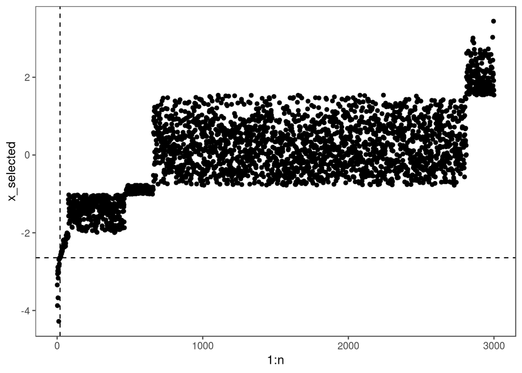

```r
gp <-
  qplot(1:n, x_selected) +
    geom_vline(xintercept = k, linetype = 2) +
    geom_hline(yintercept = x_selected[k], linetype = 2)
gp
```

Zoom in to the detail around the $k$’th element.

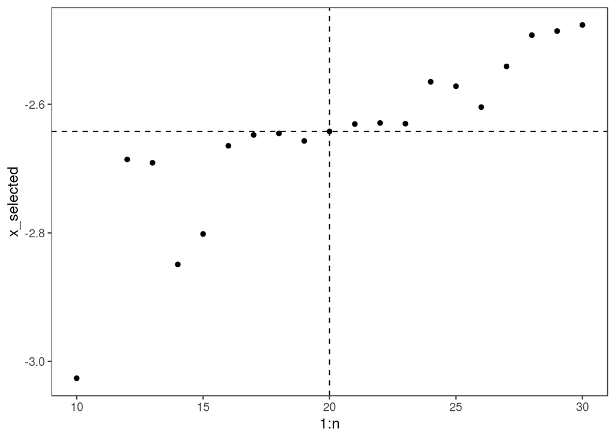

```r
gp +
  xlim(k - zoom.margin, k + zoom.margin) +
  ylim(x_selected[k - zoom.margin], x_selected[k + zoom.margin])
```

## Benchmarks

Here we use the `microbenchmark` package to show how much quicker partition-based selection is than full sorting. Note we also test finding the largest $k$ elements (`sort(x, partial = length(x) - k)`).

```r
microbenchmark(
  sort(x, partial = k),
  sort(x, partial = length(x) - k),
  sort(x)
)
```

```
## Unit: microseconds
##                              expr     min       lq      mean   median
##              sort(x, partial = k)  45.027  47.8440  51.64435  49.9335
##  sort(x, partial = length(x) - k)  43.404  45.3075  48.77798  46.7640
##                           sort(x) 142.612 144.0655 153.38552 145.2385
##        uq     max neval cld
##   52.5525 103.640   100  a
##   48.7805  97.203   100  a
##  149.2975 237.937   100   b
```

## Asymptotics

The running time should be linear in $n$. We define a function to time the partition-based selection.

```r
time_partial_sort <- function(n) {
  samples_n <- samples[1:n]
  then = proc.time()
  sort(samples_n, partial = k)
  return(proc.time() - then)
}
```

We choose 50 problem sizes ($n$) ranging from 100,000 to 100,000,000.

```r
problem_sizes <- round(10^(seq(5, 8, length.out = 50)))
```

Sample data to test with.

```r
samples <- rnorm(n = max(problem_sizes))
```

Time the partition-based selection.

```r
timings <-
  t(sapply(problem_sizes, time_partial_sort)) %>%
  as.data.frame() %>%
  mutate(n = problem_sizes)
```

Plot the elapsed times. We observe a linear relationship between the running time and $n$.

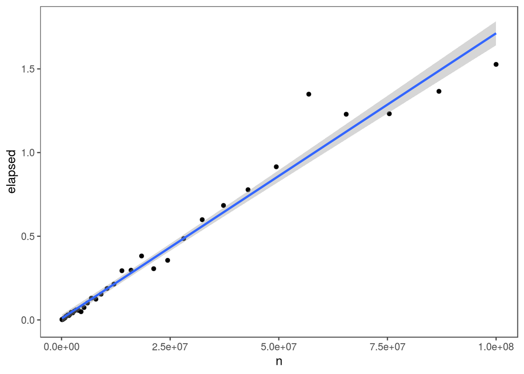

```r
ggplot(timings, aes(x = n, y = elapsed)) +
  geom_point() +
  geom_smooth(method = 'lm')
```

# Drawbacks

Frequently we are interested not in the values of the $k$ smallest elements but their indexes. Unfortunately R’s `sort()` will not let us retrieve these indexes as the `index.return = TRUE` parameter is not compatible with the `partial` argument.

```r
sort(x, partial = k, index.return = TRUE)
```

```
## Error in sort.int(x, na.last = na.last, decreasing = decreasing, ...): unsupported options for partial sorting
```

```r
kth <- sort(x, partial = k)[k]
kth
```

```
## [1] -2.642236
```

```r
indexes <- which(x <= kth)
indexes
```

```
##  [1]   74   82  305  335  347  509  594  656  744 1093 1384 1512 2003 2103
## [15] 2403 2494 2512 2638 2736 2815
```

```r
x[indexes]
```

```
##  [1] -2.664565 -2.645308 -2.801753 -2.642236 -3.058703 -2.997622 -2.690972
##  [8] -3.167249 -2.934196 -2.656970 -2.685767 -2.647660 -3.342775 -4.279542
## [15] -2.984152 -3.673439 -2.849113 -2.884244 -3.026133 -3.874028
```

Note this does not deal with ties when there is more than one $k$’th smallest element. This still has running time $\mathcal{O}(n + k \log k)$ but with a worse constant and memory requirements.

A more sophisticated approach could build upon this Rcpp [example](http://gallery.rcpp.org/articles/sorting/).